# 2장. 그래프

### 1절. 점 그래프

#### 1. 점 그래프

- points(x,y=NULL,pch,cex,col)

#### 2. R을 활용해 점 그래프 그리기

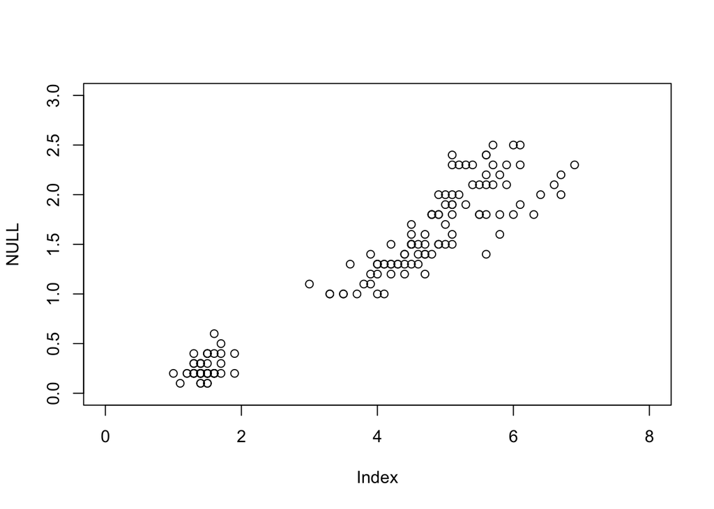

```r
plot(NULL, type='n',xlim=c(0,8),ylim=c(0,3))
points(iris$Petal.Length,iris$Petal.Width)
```

### 2절. 선 그래프

#### 1. 꺽은선 그래프

- lines(x, y=NULL, …)

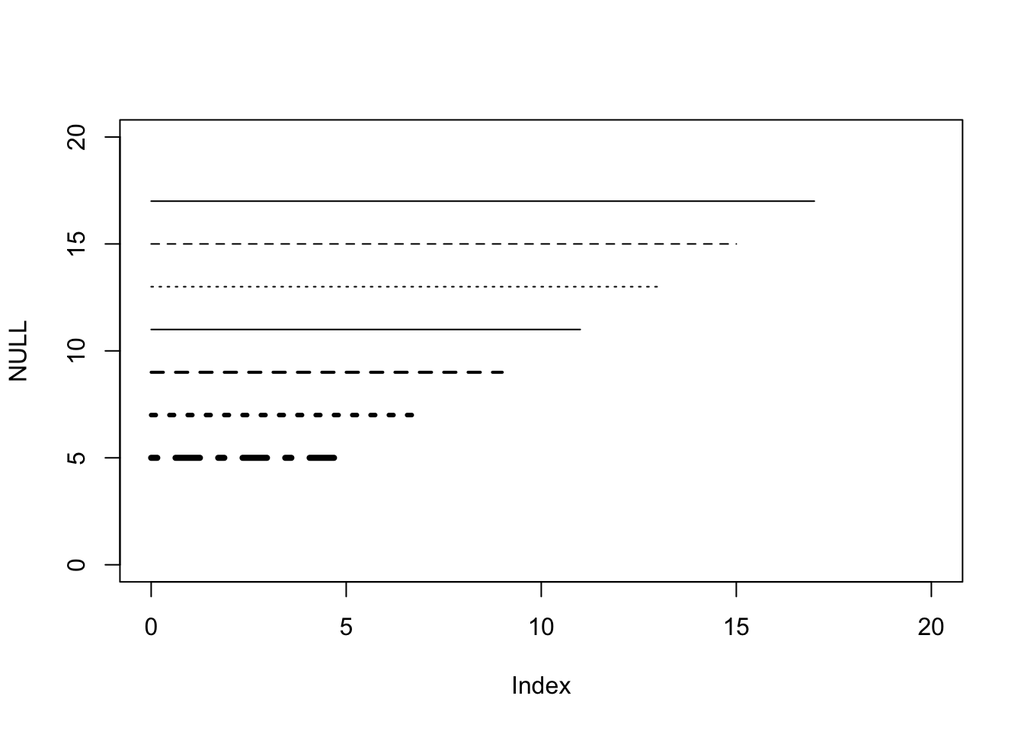

```r
plot(NULL, type='n',xlim=c(0,20),ylim=c(0,20))

lines(c(0,17),c(17,17), lty=1)
lines(c(0,15),c(15,15), lty=2)
lines(c(0,13),c(13,13), lty=3)

lines(c(0,11),c(11,11), lty=1, lwd=1)
lines(c(0,9),c(9,9), lty=2, lwd=2)
lines(c(0,7),c(7,7), lty=3, lwd=3)
lines(c(0,5),c(5,5), lty=4, lwd=4)
```

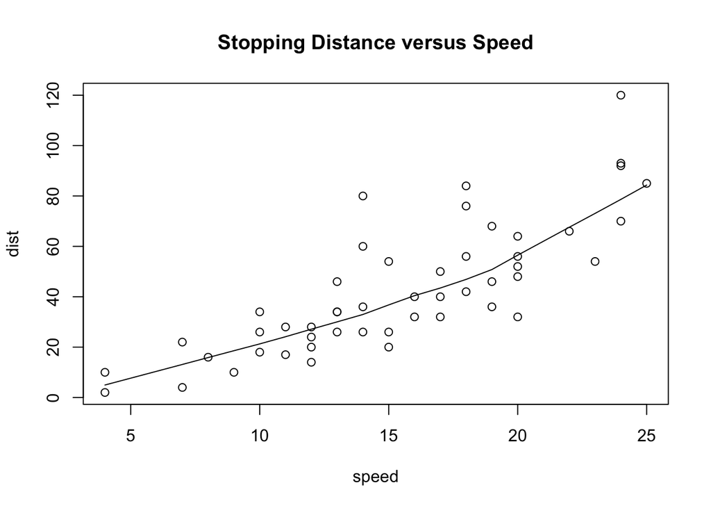

```r
plot(cars, main='Stopping Distance versus Speed')

lines(lowess(cars))
```

#### 2. 직선 그래프

- abline(a=NULL, b=NULL, h=NULL, v=NULL, coef=NULL, reg=NULL,…)

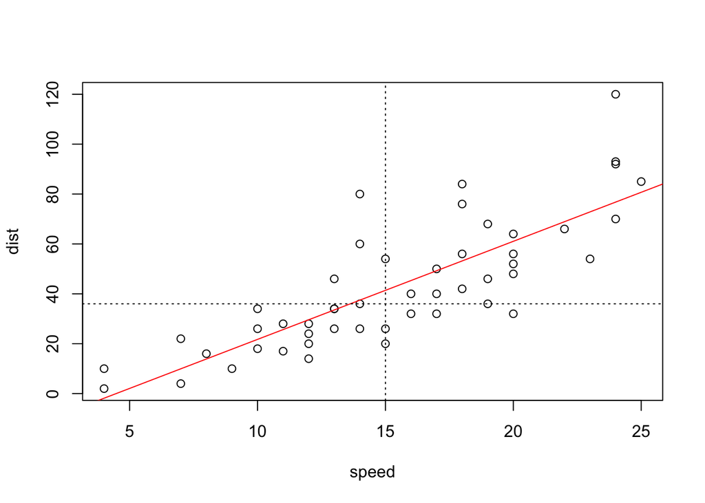

```r
plot(cars)
cars_lm <- lm(dist~speed, data = cars)
abline(cars_lm, col='red')
abline(v=median(cars$speed), lty=3)
abline(h=median(cars$dist), lty=3)
```

#### 3. 곡선 그래프

: 곡선 그래프를 시작점에서 끝점까지 그려주는 함수

- curve(expr, from=NULL, to=NULL,…)

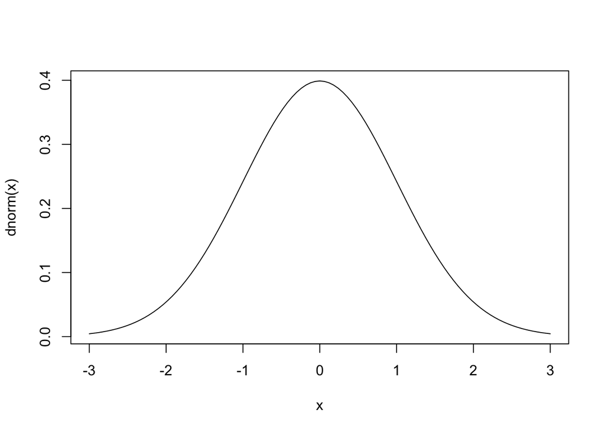

```r
curve(dnorm(x), from = -3, to = 3)
```

### 3절. 막대 그래프

#### 2. R을 활용해 막대 그래프 그리기

i. 단일 범주형 변수

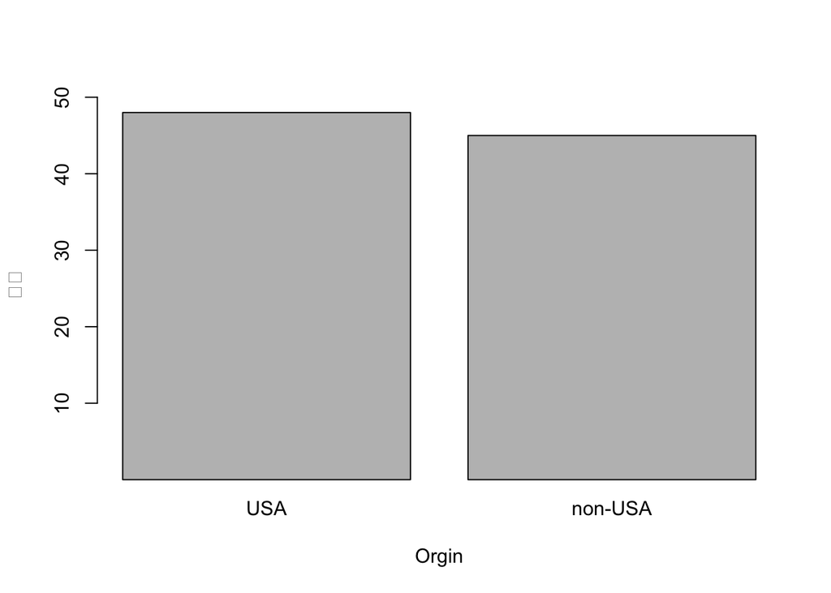

```r
library(MASS)

barplot(table(Cars93$Origin), ylim = c(1,50),
        xlab = 'Orgin', ylab = '도수')
```

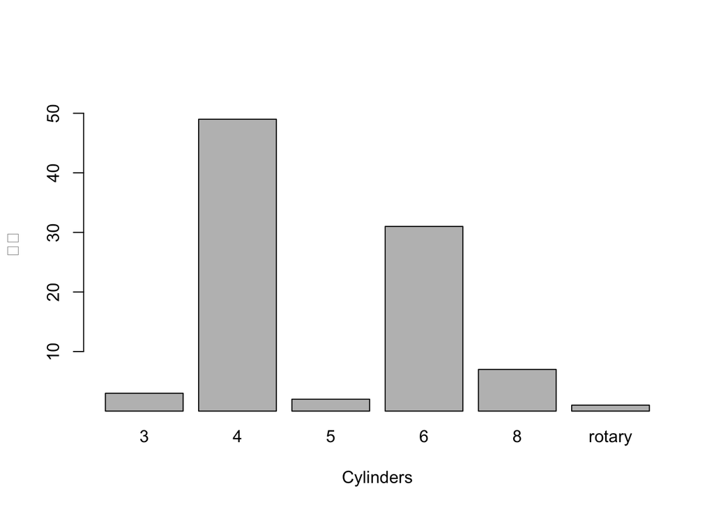

```r
barplot(table(Cars93$Cylinders),ylim = c(1,55),
        xlab = 'Cylinders', ylab = '도수')
```

ii. 여러 개의 범주형 변수

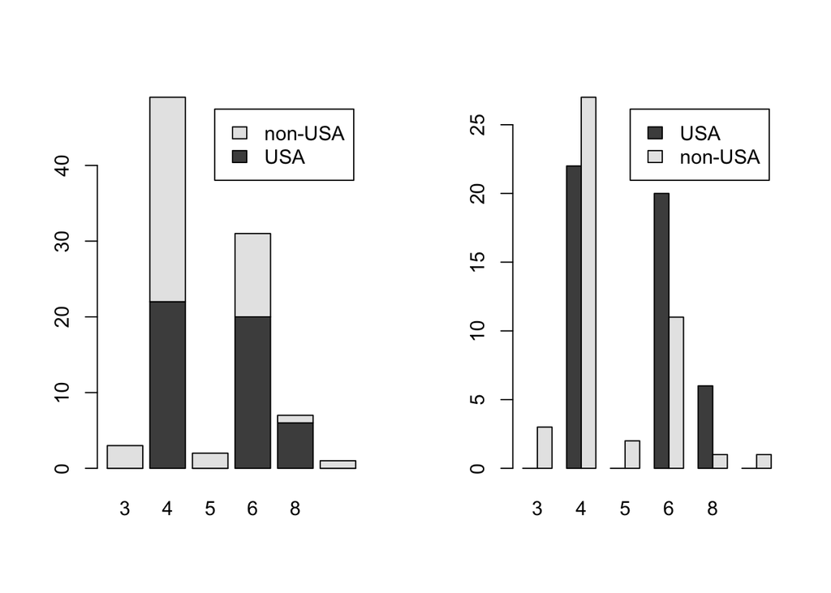

```r
library(MASS)

par(mfrow=c(1,2))

barplot(table(Cars93$Origin,Cars93$Cylinders),beside = F,legend=T)
barplot(table(Cars93$Origin,Cars93$Cylinders),beside = T,legend=T)
```

### 4절. 히스토그램

#### 1. 히스토그램

- hist(x, main,xlab,ylab, breaks, freq, col)
  - breaks : 막대의 구간
  - freq : 구간별 데이터의 개수(빈도)를 표시할지의 여부 (TRUE : 개수 / FALSE : 확률밀도)

#### 2. R을 활용해 히스토그램 그리기

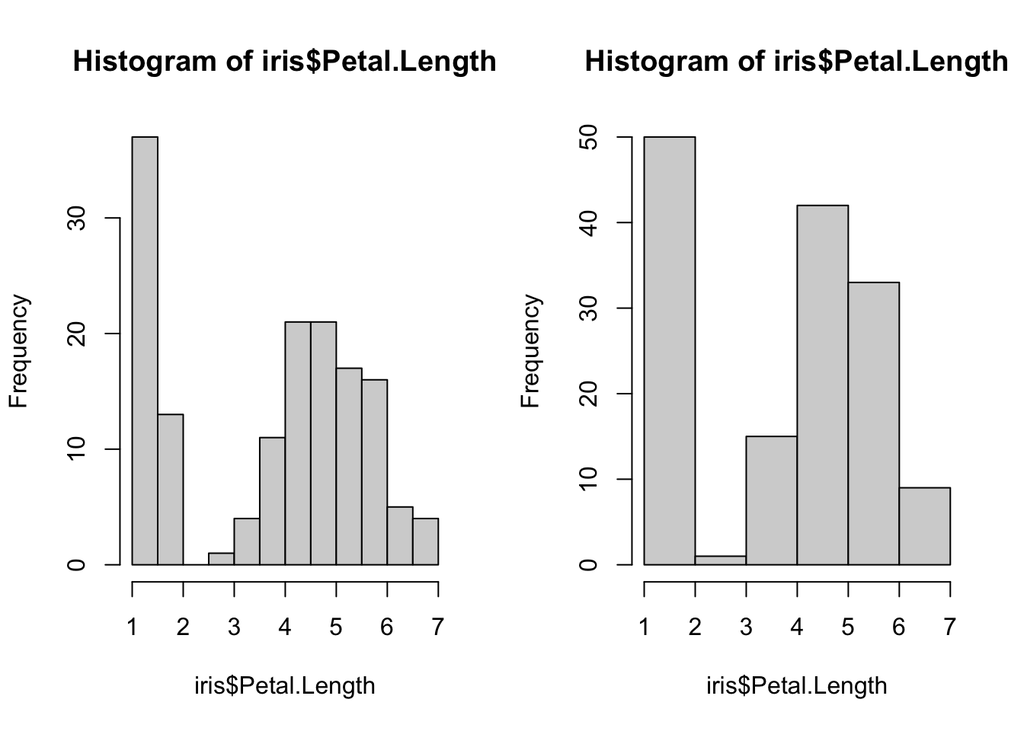

```r
par(mfrow=c(1,2))

hist(iris$Petal.Length)
hist(iris$Petal.Length, breaks = 5)
```

### 5절. 파이 차트

#### 1. 파이 차트

- pie(x, labels,col,lty,main)
  - labels : 파이차트에 각 부분에 해당하는 이름, 반시계방향으로 부여

#### 2. R을 활용해 파이 차트 그리기

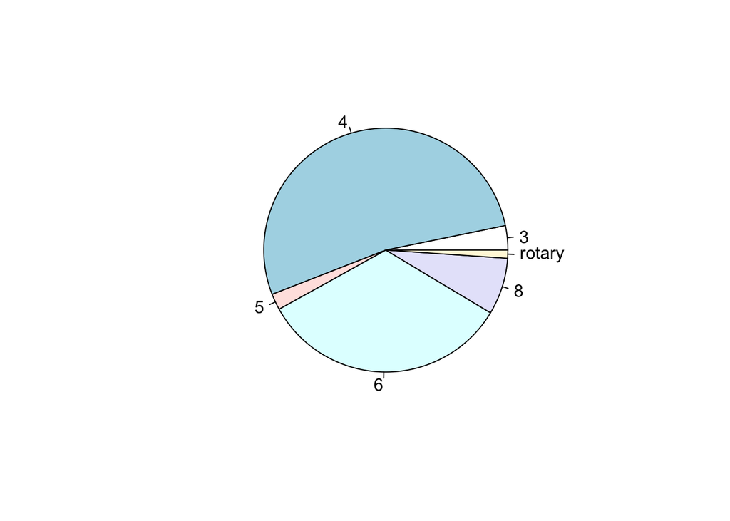

```r
pie(table(Cars93$Cylinders))
```

### 6절. 산점도 행렬

#### 1. 산점도 행렬

- pairs(x, labels)
- pairs(formula, data=NULL, subset)
  - subset : 특정 조건을 만족하는 일부 데이터만 추출

#### 2. R을 활용해 산점도 행렬 그리기

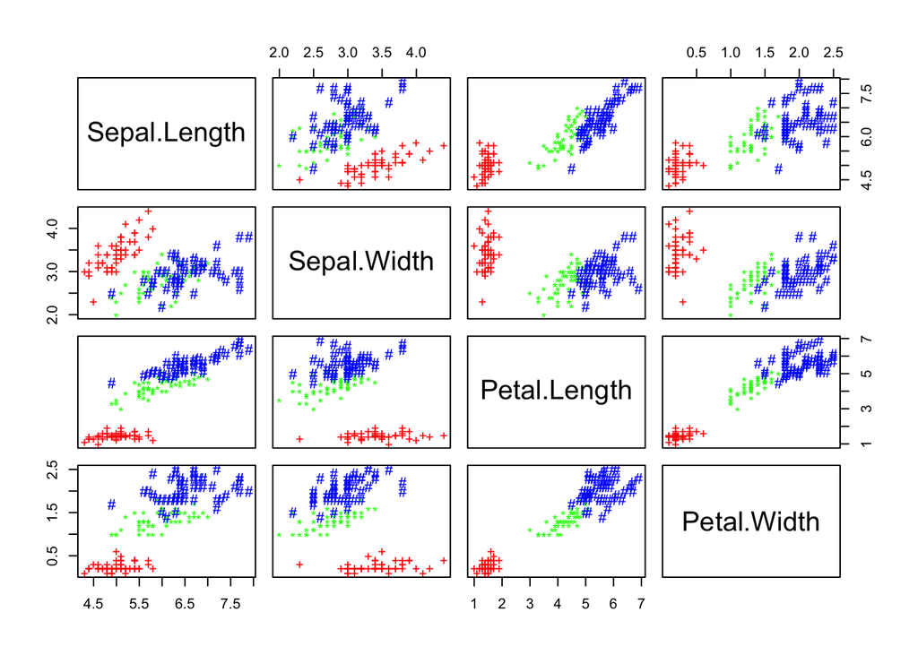

```r
pairs(~Sepal.Length+Sepal.Width+Petal.Length+Petal.Width,
      data=iris, col=c('red','green','blue')[iris$Species],
      pch=c('+','*','#')[iris$Species])
```